# Užduotis „Viščiukų pašarų priedai“

S15-1 (su sprendimu)

2022-05-23

# 1 Užuotis

Atliktas tyrimas, kurio metu viščiukai buvo atsitiktinai suskirstyti į 6 grupes, kurioms 6 savaites buvo duodami skirtingi maisto papildai. Šiam eksperimento etapui pasibaigus buvo išmatuotas viščiukų svoris gramais. Įvertinkite, kuris maisto papildas buvo efektyviausias siekiant užauginti didesnio svorio paukščius.

Duomenys „papildai“ pateikti žemiau.

**Pastaba:** kaip įprasta moksliniams tyrimams, jūs išvadas turite daryti ne apie konkrečiai šiuos eksperimente dalyvavusius (naudotus) gyvūnus, o apie pašaro įtaką apskritai.

# 2 Sprendimas

```r
# Paketai --------------------------------------------------------------------
library(conflicted)
library(tidyverse)

# Grafikams
library(ggpubr)

# Statistinei analizei
library(DescTools)
library(rstatix)
library(ggpubr)
library(PMCMRplus)
library(effectsize)

# Nustatymai -----------------------------------------------------------------
knitr::opts_chunk$set(
  eval       = TRUE,
  fig.height = 3,
  fig.width  = 7,
  fig.align  = "center"
)

# Jei naudojate R ≥ 4.2.0, tai lokalės keisti nebūtina
# (t.y., su lokalės keitimu susijusias 5 eilutes galite ištrinti)
if (getRversion() < "4.2.0" && tolower(Sys.info()[['sysname']]) == "windows") {
  Sys.setlocale(locale = "Lithuanian")    # Windows ir R < 4.2.0
} else {
  Sys.setlocale(locale = "lt_LT.UTF-8")   # Linux, Mac arba R ≥ 4.2.0
}

ggplot2::theme_set(ggplot2::theme_bw())

conflict_prefer("cohens_d", "rstatix")

# === Papildomos funkcijos ===================================================
# Jūsų projekte turi būti byla "funkcijos/sudaryk_cld.R"
source("funkcijos/sudaryk_cld.R", encoding = "UTF-8")
# ========================================================================== ~
```

## 2.1 Duomenys

```r
# Duomenų dokumentacija
help("chickwts", package = "datasets")
```

Duomenų įkėlimas ir pertvarkymas, kad pavadinimai atitiktų šablone naudojamus (t.y., kad nebereiktų modifikuoti kitur). Papildomai pakeičiami grupių pavadinimai (to daryti nebūtina).

```r
data("chickwts", package = "datasets")

# Kodo šitame bloke nekeisti
# transmute() = mutate() ir select()
papildai <-
  chickwts %>%
  dplyr::transmute(
    papildas = dplyr::recode_factor(feed,
      "casein"    = "kazeinas",
      "horsebean" = "arkliapupes",
      "linseed"   = "semenys",
      "meatmeal"  = "mesos miltai",
      "soybean"   = "soja",
      "sunflower" = "saulegrazos"
    ),
    svoris = weight
  )
```

```r
duomenys <-
  papildai %>%
  rename(grupe = papildas, y = svoris)
```

```r
head(duomenys)
```

|  | grupe | y |
| --- | --- | --- |
| 1 | arkliapupes | 179 |
| 2 | arkliapupes | 160 |
| 3 | arkliapupes | 136 |
| 4 | arkliapupes | 227 |
| 5 | arkliapupes | 217 |
| 6 | arkliapupes | 168 |

```r
glimpse(duomenys)
```

```
## Rows: 71
## Columns: 2
## $ grupe <fct> arkliapupes, arkliapupes, arkliapupes, arkliapupes, arkliapupes,…
## $ y     <dbl> 179, 160, 136, 227, 217, 168, 108, 124, 143, 140, 309, 229, 181,…
```

```r
duomenys %>% count(grupe)
```

| grupe | n |
| --- | --- |
| kazeinas | 12 |
| arkliapupes | 10 |
| semenys | 12 |
| mesos miltai | 11 |
| soja | 14 |
| saulegrazos | 12 |

## 2.2 Duomenų suvestinės pagal klausimą

```r
Desc(y ~ grupe, data = duomenys, verbose = 3, plotit = FALSE)
```

```
## ------------------------------------------------------------------------------
## y ~ grupe (duomenys)
##
## Summary:
## n pairs: 71, valid: 71 (100.0%), missings: 0 (0.0%), groups: 6
##
##
##             kazeinas   arkliapupes       semenys  mesos miltai          soja
## mean         323.583       160.200       218.750       276.909       246.429
## median       342.000       151.500       221.000       263.000       248.000
## sd            64.434        38.626        52.236        64.901        54.129
## IQR           93.500        39.250        79.750        70.500        63.250
## n                 12            10            12            11            14
## np           16.901%       14.085%       16.901%       15.493%       19.718%
## NAs                0             0             0             0             0
## 0s                 0             0             0             0             0
## min          216.000       108.000       141.000       153.000       158.000
## max          404.000       227.000       309.000       380.000       329.000
## Q1           277.250       137.000       178.000       249.500       206.750
## Q3           370.750       176.250       257.750       320.000       270.000
## mad           63.010        32.617        58.563        77.095        53.374
## skew          -0.461         0.471         0.009        -0.245         0.028
## kurt          -1.374        -1.195        -1.331        -0.930        -1.174
##
##          saulegrazos
## mean         328.917
## median       328.000
## sd            48.836
## IQR           27.500
## n                 12
## np           16.901%
## NAs                0
## 0s                 0
## min          226.000
## max          423.000
## Q1           312.750
## Q3           340.250
## mad           18.532
## skew          -0.054
## kurt           0.059
##
## Kruskal-Wallis rank sum test:
##   Kruskal-Wallis chi-squared = 37.343, df = 5, p-value = 5.113e-07
```

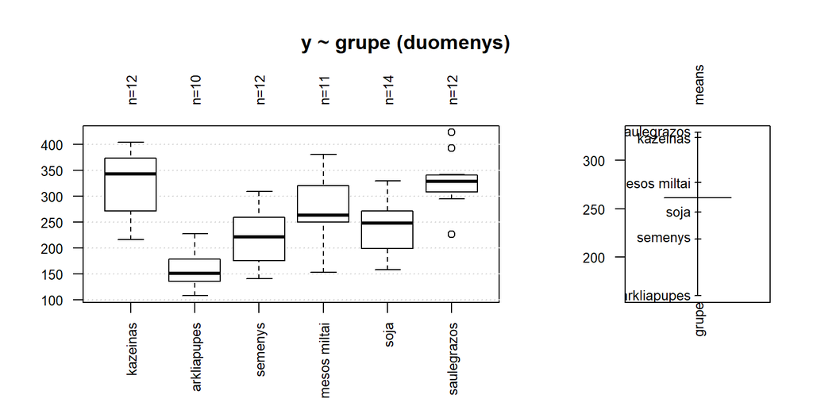

```r
par(las = 2) # Pasuka užrašus bazinės „R“ sistemos (bet ne ggplot2) grafikuose
plot(Desc(y ~ grupe, data = duomenys))
```

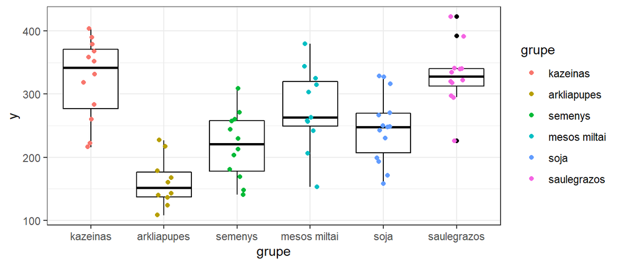

```r
duomenys %>%
  ggplot(aes(y = y, x = grupe, color = grupe)) +
  geom_boxplot(color = "black") +
  geom_jitter(width = 0.1)
```

Grupių dydžiai nedideli (tarp 10 ir 14 viščiukų grupėje). Grupių padėtis, panašu, skirtinga (tad reikia įvertinti ir stat. reikšmingumą), o sklaida taip pat atrodo, kad bent šiek tiek skiriasi, tačiau ar tai darys įtaką tolimesnei analizei, reiktų panagrinėti detaliau.

## 2.3 Prielaidų tikrinimas

**Išskirčių paieška.**

```r
duomenys %>% group_by(grupe) %>% identify_outliers(y)
```

| grupe | y | is.outlier | is.extreme |
| --- | --- | --- | --- |
| saulegrazos | 423 | TRUE | TRUE |
| saulegrazos | 392 | TRUE | FALSE |
| saulegrazos | 226 | TRUE | TRUE |

Nors kai kurie taškai pripažįstami kaip išskirtys, jie yra simetriškai nutolę nuo vidurkio (žiūrėkite išplėstinėje stačiakampėje diagramoje viršuje). Be to, iš paklaidų QQ grafiko (žemiau) matome, kad ypač didelės įtakos normalumui neturi.

*Normalumo prielaidos tikrinimas.*

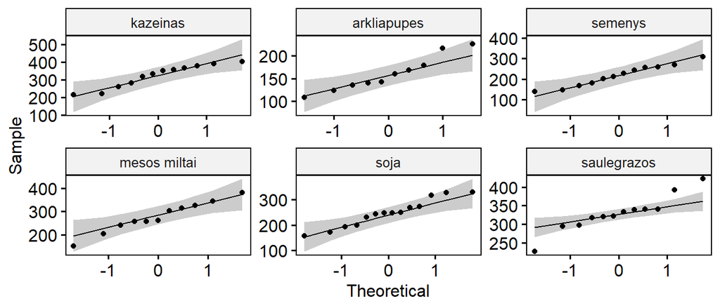

```r
duomenys %>% ggqqplot("y", facet.by = "grupe", scales = "free")
```

```r
duomenys %>% group_by(grupe) %>% shapiro_test(y)
```

| grupe | variable | statistic | p |
| --- | --- | --- | --- |
| kazeinas | y | 0.9166257 | 0.2591841 |
| arkliapupes | y | 0.9375834 | 0.5264499 |
| semenys | y | 0.9693128 | 0.9034734 |
| mesos miltai | y | 0.9791381 | 0.9611795 |
| soja | y | 0.9464029 | 0.5063768 |
| saulegrazos | y | 0.9280884 | 0.3602904 |

Imtys mažos (< 20), todėl statistiniam kriterijui gali nepakakti galios atmesti H₀ (parodyti prielaidos pažeidimus). Tačiau sprendžiant ir pagal QQ diagramą, labai ryškių normalumo prielaidos pažeidimų nėra.

Padarome išvadą, kad normalumo prielaida tenkinama.

**Lygių dispersijų prielaidos tikrinimas.**

```r
# Dispersijų ir SD skaičiavimas ir santykis tarp didžiausios ir mažiausios reikšmių
duomenys %>%
  group_by(grupe) %>%
  summarise(dispersija = var(y), SD = sd(y)) %>%
  ungroup() %>%
  mutate(
    max_min_dispersiju_santykis = round(max(dispersija) / min(dispersija), 1),
    max_min_SD_santykis         = round(max(SD)         / min(SD),         1)
  )
```

| grupe | dispersija | SD | max_min_dispersiju_santykis | max_min_SD_santykis |
| --- | --- | --- | --- | --- |
| kazeinas | 4151.720 | 64.43384 | 2.8 | 1.7 |
| arkliapupes | 1491.956 | 38.62584 | 2.8 | 1.7 |
| semenys | 2728.568 | 52.23570 | 2.8 | 1.7 |
| mesos miltai | 4212.091 | 64.90062 | 2.8 | 1.7 |
| soja | 2929.956 | 54.12907 | 2.8 | 1.7 |
| saulegrazos | 2384.992 | 48.83638 | 2.8 | 1.7 |

```r
duomenys %>% levene_test(y ~ grupe)
```

| df1 | df2 | statistic | p |
| --- | --- | --- | --- |
| 5 | 65 | 0.7492639 | 0.5896095 |

Skirtumai tarp dispersijų < 3 kartus. Levene kriterijaus rezultatas taip pat nerodo stat. reikšmingų nuokrypių (nors dėl mažo grupių dydžio šiuo rezultatu per daug kliautis nereikėtų).

Padarome išvadą, kad lygių dispersijų prielaida tenkinama.

## 2.4 Pagrindinė analizė: **[A]** ANOVA

```r
anova_rez <- duomenys %>% anova_test(y ~ grupe, detailed = TRUE)
```

```
## Coefficient covariances computed by hccm()
```

```r
anova_rez # `ges` yra η² („generalized eta squared“, η²)
```

|  | Effect | SSn | SSd | DFn | DFd | F | p | p<.05 | ges |
| --- | --- | --- | --- | --- | --- | --- | --- | --- | --- |
| 1 | grupe | 231129.2 | 195556 | 5 | 65 | 15.365 | 5.94e-10 | * | 0.542 |

```r
get_test_label(anova_rez, type = "text", detailed = TRUE)
```

```
## [1] "Anova, F(5,65) = 15.37, p = <0.0001, eta2[g] = 0.542"
```

```r
with(anova_rez, effectsize::F_to_omega2(f = F, df = DFn, df_error = DFd, ci = .95))
```

| Omega2_partial | CI | CI_low | CI_high |
| --- | --- | --- | --- |
| 0.5028881 | 0.95 | 0.3379161 | 1 |

Skirtumai tarp grupių statistiškai reikšmingi (*p* < 0,001) ir skirtumais, atsiradusiais dėl skirtingų pašarų naudojamo, paaiškinama 50 % svorių dispersijos (ω² = 0,50, 95% PI 0,34–1,00).

Toliau pasiaiškinkime, kurios grupės tarpusavyje skiriasi statistiškai reikšmingai. Kadangi grupių dydžiai nėra visiškai vienodi ir dispersijos įverčiai skiriasi apie 2,8 karto, tai naudosime Games-Howell kriteijų.

## 2.5 **[b]** *Post-hoc:* Games-Howell kriterijus

**Reikšmingumo tikrinimas.**

Statistinį reikšmingumą vertinti pagal `p.adj` (koreguotoji *p*).

```r
# Lygina kiekvieną grupę su kiekviena
gh_test_rez <-
  duomenys %>%
  games_howell_test(y ~ grupe, conf.level = 0.95, detailed = TRUE)

gh_test_rez
```

|  | .y. | group1 | group2 | n1 | n2 | estimate | conf.low | conf.high | se | statistic | df | p.adj | p.adj.signif | method |
| --- | --- | --- | --- | --- | --- | --- | --- | --- | --- | --- | --- | --- | --- | --- |
| 1 | y | kazeinas | arkliapupes | 12 | 10 | -163.383333 | -233.950009 | -92.816657 | 15.73487 | 7.3422577 | 18.35975 | 9.44e-06 | **** | Games-Howell |
| 2 | y | kazeinas | semenys | 12 | 12 | -104.833333 | -179.712125 | -29.954542 | 16.93159 | 4.3781104 | 21.09735 | 3.00e-03 | ** | Games-Howell |
| 3 | y | kazeinas | mesos miltai | 12 | 11 | -46.674242 | -131.214384 | 37.865899 | 19.09049 | 1.7288013 | 20.79857 | 5.29e-01 | ns | Games-Howell |
| 4 | y | kazeinas | soja | 12 | 14 | -77.154762 | -150.671109 | -3.638415 | 16.66222 | 3.2742727 | 21.63451 | 3.60e-02 | * | Games-Howell |
| 5 | y | kazeinas | saulegrazos | 12 | 12 | 5.333333 | -67.850731 | 78.517397 | 16.50342 | 0.2285123 | 20.50231 | 1.00e+00 | ns | Games-Howell |
| 6 | y | arkliapupes | semenys | 10 | 12 | 58.550000 | -2.517348 | 119.617348 | 13.72181 | 3.0171746 | 19.76872 | 6.50e-02 | ns | Games-Howell |
| 7 | y | arkliapupes | mesos miltai | 10 | 11 | 116.709091 | 42.673776 | 190.744406 | 16.31124 | 5.0594439 | 16.52352 | 1.00e-03 | *** | Games-Howell |
| 8 | y | arkliapupes | soja | 10 | 14 | 86.228571 | 27.246961 | 145.210182 | 13.38802 | 4.5542814 | 21.99541 | 2.00e-03 | ** | Games-Howell |
| 9 | y | arkliapupes | saulegrazos | 10 | 12 | 168.716667 | 110.074065 | 227.359268 | 13.18986 | 9.0448784 | 19.96372 | 2.31e-07 | **** | Games-Howell |
| 10 | y | semenys | mesos miltai | 12 | 11 | 58.159091 | -19.798379 | 136.116561 | 17.46852 | 2.3542177 | 19.23610 | 2.21e-01 | ns | Games-Howell |

[output cut: 5 more lines]

`estimate` stulpelis rodo skirtumus tarp grupių (gramais), o `conf.low` ir `conf.high` – šio skirtumo 95 % pasikliautinąjį intervalą (PI). Tai galime panaudoti aprašydami rezultatus. Šalia šių rezultatų pakeiksime ir efekto dydį $d^*$ (aprašydami rezultatus padarykite, kad ženklas +/- ties standartizuotu skirumu $d^*$ ir skirtumu pradiniais matavimo vienetais sutaptų).

```r
# Naudotų metodų apibūdinimas
get_pwc_label(gh_test_rez, type = "text")
```

```
## [1] "pwc: Games Howell; p.adjust: Tukey"
```

**CLD.** Rezultatų apibendrinimas kompaktišku raidiniu žymėjimu.

```r
cld_rez_gh <- sudaryk_cld(gh_test_rez, alpha = 0.05)
cld_rez_gh
```

| group | cld | cld_sulygiuota |
| --- | --- | --- |
| kazeinas | a | a__ |
| arkliapupes | b | _b_ |
| semenys | bc | _bc |
| mesos miltai | ac | a_c |
| soja | c | __c |
| saulegrazos | a | a__ |

**Efekto dydis poroms.**

```r
# Koreguotasis Koheno d* (su Hedžo pataisa)
efekto_dydis_poroms_d <-
  duomenys %>%
  rstatix::cohens_d(y ~ grupe, hedges.correction = TRUE) %>%
  arrange(desc(abs(effsize))) # Išrikiuoja eilutes pagal efekto dydį

efekto_dydis_poroms_d
```

| .y. | group1 | group2 | effsize | n1 | n2 | magnitude |
| --- | --- | --- | --- | --- | --- | --- |
| y | arkliapupes | saulegrazos | -3.68650221 | 10 | 12 | large |
| y | kazeinas | arkliapupes | 2.95888607 | 12 | 10 | large |
| y | semenys | saulegrazos | -2.10360181 | 12 | 12 | large |
| y | arkliapupes | mesos miltai | -2.09797056 | 10 | 11 | large |
| y | arkliapupes | soja | -1.77060299 | 10 | 14 | large |
| y | kazeinas | semenys | 1.72572314 | 12 | 12 | large |
| y | soja | saulegrazos | -1.54960485 | 14 | 12 | large |
| y | kazeinas | soja | 1.25566543 | 12 | 14 | large |
| y | arkliapupes | semenys | -1.22615458 | 10 | 12 | large |
| y | semenys | mesos miltai | -0.95157746 | 12 | 11 | large |

[output cut: 5 more lines]

Čia `effsize` yra efekto dydis, tekste žymimas $d^*$.

# 3 Atsakymas

```r
# Lentelės kodas

duomenys %>%
  group_by(grupe) %>%
  summarise(
    Vidurkis = mean(y),
    SD       = sd(y),
    n        = n()
  ) %>%
  rename("Papildas" = "grupe") %>%
  arrange(desc(Vidurkis)) %>%
  knitr::kable(
    digits  = 0,
    caption = "**Lentelė 1.** Viščiukų grupių, kurios gavo skirtingus pašarus,
    svorio suvestinė.
    Matavimo vienetai – gramai. SD -- standartinis nuokrypis, n -- imties dydis.  ",
    format  = "pandoc"
  )
```

```r
# Paveikslo kodas

cap_fig_1 = "**Pav. 1.** Grafinis analizės rezultatų apibendrinimas Tukio
stiliaus stačiakampėmis diagramomis.
*Post-hoc* porinių lyginimų Games-Howell metodu rezultatai apibendrinti
kompaktišku raidiniu žymėjimu, kur bendra raidė tarp grupių rodo statistiškai
nereikšmingus skirtumus ($\\alpha$ = 0,05), o bendros raidės nebuvimas –
statistiškai reikšmingus. Dideli taškai centre vaizduoja vidurkius.  "

# Aukštis y ašyje, ties kuriuo pateikta CLD etiketė grafike.
# Galite įrašyti konkretų skaičių.
y_koordinate <- max(duomenys$y) + diff(range(duomenys$y)) * 0.1

duomenys %>%
  ggboxplot(
    y     = "y",
    x     = "grupe",
    color = "grupe",
    add   = "mean",
    ylim  = c(0, y_koordinate),
    legend = "right",
    legend.title = "Pašaras",
    xlab = "",
    ylab = "Svoris, g"

  ) +
  rotate_x_text(angle = 30) +
  geom_text(aes(label = cld, x = group), y = y_koordinate, data = cld_rez_gh)
```

*(Atsakymas)*

Tyrime analizuota 6 pašarų papildų įtaka viščiukų svoriui. Grupių duomenys apibendrinti lentelėje 1. ANOVA analizė atskleidė, kad pašarų papildų įtaka svoriui yra statistiškai reikšminga, $F$(5; 65) = 15,37, $p$ = <0.001, $ω²$ = 0,50, n = 71. Apibendrinti porinių lyginimų Games-Howell metodu rezultatai pateikti pav. 1. Didžiausiu vidutiniu svoriu pasižymėjo saulėgrąžų gavusi grupė, tačiau jos vidurkio skirtumas nuo kazeino gavusios (vid.skirtumas – 5 g, 95% PI [-68 – +79], $p^*$ > 0,999, $d^*$ = 0,09) ir mėsos miltų gavusios (vid.skirtumas – 52 g, 95% PI [-24 – +128], $p^*$ = 0,303, $d^*$ = 0,87) grupių buvo statistiškai nereikšmingas, o nuo likusių grupių – reikšmingas (α = 0,05). Rezultatai apibendrinti pav. 1.

Žymėjimai: n – imties dydis, efekto dydžiai $ω²$ (grupių skirtumais paaiškintos dispersijos dalis) ir $d^*$ (Koreguotasis Koheno $d^*$ – skirtumas standartiniais nuokrypiais), $p^*$ – Games-Howell kriterijaus koreguotoji $p$ reikšmė, PI – pasikliautinasis intervalas, α – reikšmingumo lygmuo.

**Pastabos studentams:**

1. rezultatus nagrinėti bei atsakyti galima ir išsamiau;
2. koeficiento $d^*$ ir skirtumo ženklas (+ arba -) turi sutapti: rezultatuose vieną karta pirma laikyta viena grupė, po to – kita. Todėl rezultatų lentelėse buvo pateikta $d^*$ = -0,87, o aprašyme panaudota $d^*$ = 0,87 (t.y., teigiama reikšmė).

**Lentelė 1.** Viščiukų grupių, kurios gavo skirtingus pašarus, svorio suvestinė. Matavimo vienetai – gramai. SD – standartinis nuokrypis, n – imties dydis.

| Papildas | Vidurkis | SD | n |
| --- | --- | --- | --- |
| saulegrazos | 329 | 49 | 12 |
| kazeinas | 324 | 64 | 12 |
| mesos miltai | 277 | 65 | 11 |
| soja | 246 | 54 | 14 |
| semenys | 219 | 52 | 12 |
| arkliapupes | 160 | 39 | 10 |

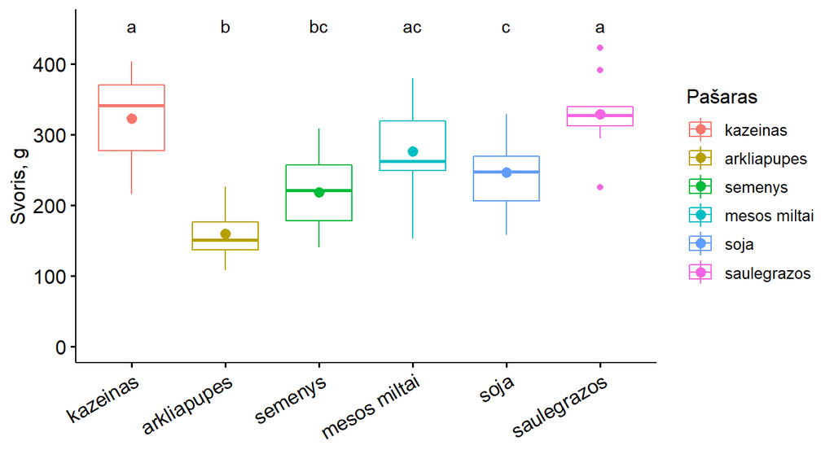

**Pav. 1.** Grafinis analizės rezultatų apibendrinimas Tukio stiliaus stačiakampėmis diagramomis. *Post-hoc* porinių lyginimų Games-Howell metodu rezultatai apibendrinti kompaktišku raidiniu žymėjimu, kur bendra raidė tarp grupių rodo statistiškai nereikšmingus skirtumus ($\alpha$ = 0,05), o bendros raidės nebuvimas – statistiškai reikšmingus. Dideli taškai centre vaizduoja vidurkius.

*(Atsakymo modifikacija, kai tekste nepateikiama statistinės analizės detalių, nes, pvz., jos pateikiamos lentelėje)*

… Didžiausiu vidutiniu svoriu pasižymėjo saulėgrąžų gavusi grupė, tačiau vidutinis jos skirtumas nuo grupių, kurios gavo kazeino ir mėsos miltų, buvo statistiškai nereikšmingas, o nuo likusių (arkliapupės, sėmenys, soja) – reikšmingas (α = 0,05). Rezultatai apibendrinti pav. 1. …

**Pastaba:** sprendžiant pratybų užduotis reikia pateikti pilną atsakymą su reikiamomis statistinės analizės detalėmis.